# EDA Results

Sander J. Bouwman

10/5/2021

## Results

### Age

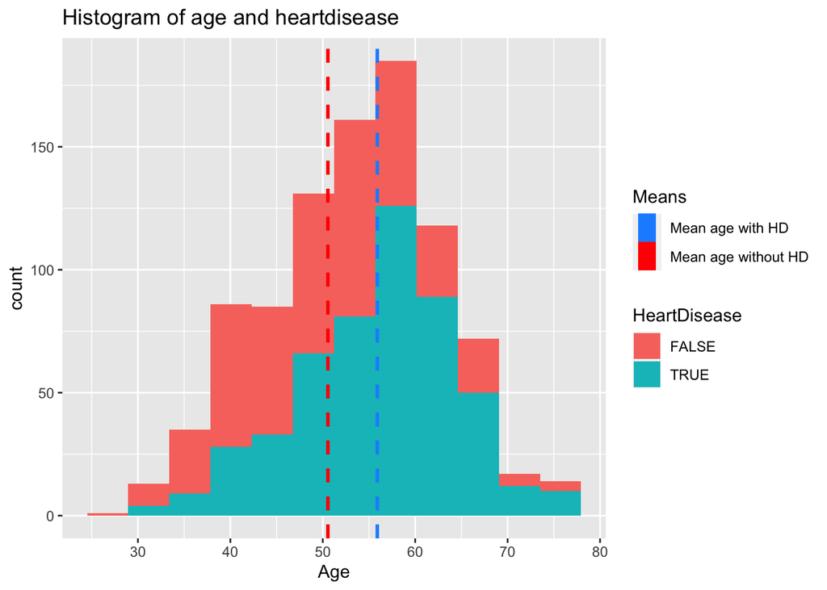

Fig 1. histogram of age grouped by heartdisease diagnoses

In the figure above (fig 1) it is visible that the percentage of patients with heartdisease (HD) shifts to a majority with age. After the age of around 70, this percentage seems to shrink again. Using the dotted vertical lines we can see that there is a difference in mean age in persons with or without HD. The mean age of persons with HD is ~56 years whereas the mean age of persons without HD is ~51 years. The histogram is itself shows a descent normal distribution in age in the dataset. To further explore the possible relation/correlation between age and the prevelance of HD another plot is used.

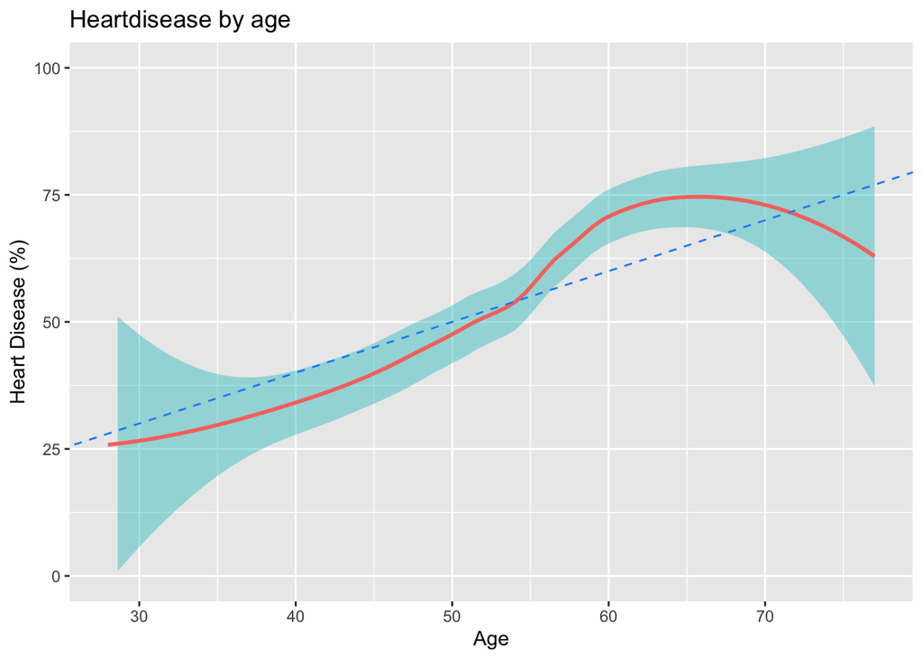

Fig 2. Percentage of patients affected by HD by age

Figure 2 shows the relation between age and prevalance of HD. Both ends show a major wide area of heart disease (percentage) while the overal trend shows a clear increase of heartdisease with an increase of age. The percentage of patients with a positive HD diagnosis at age 30 is around 25% wheras patients age 65 have a 75% positive diagnosis rate. As visible both figure 1 and in figure 2 it is visible that the percentage of positive diagnosis lowers after age 65.

### Sex

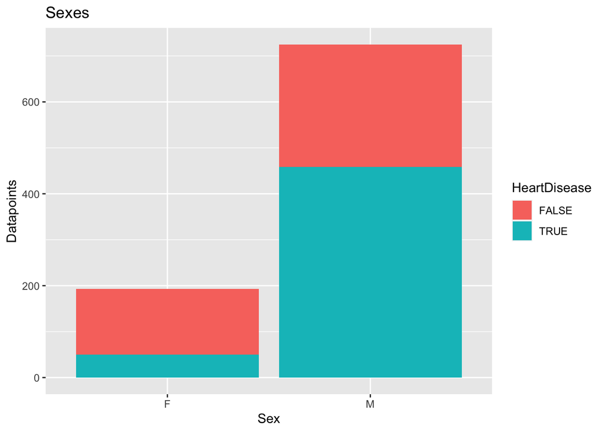

Fig 3. Amount of instances by sex grouped by HD diagnosis

As visible in the above figure (fig 3) the ratio of female(21.02%) to male(78.98%) is very skewed towards males. The ratio of a positive diagnosis is obviously different. Males tend to have on average a positive HD diagnosis whereas females have a negative diagnosis.

To further visiualize if the density of age with sex is roughtly the same the underlying figure was generated.

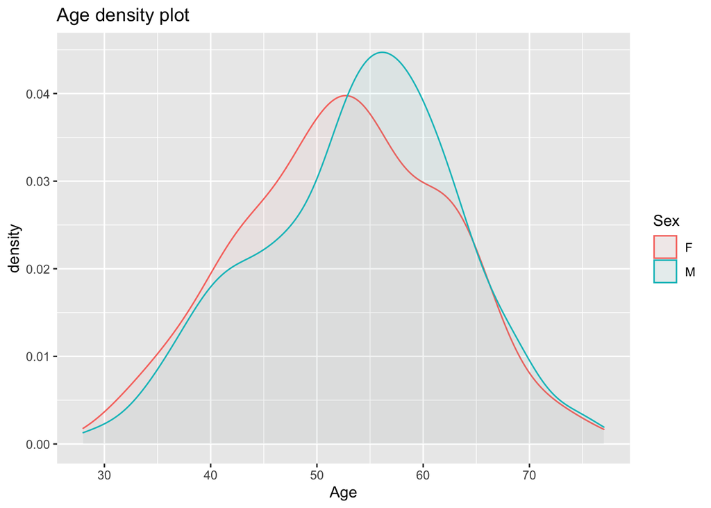

Fig 4. Density plot of ages grouped by sex

Figure 4 shows that both sexes have an about even amount of age groups. Where males have a higher representation in the ages 55+ years, and females have a larger (relative for females) representation lower then 55 years.

### Pain types

To bring an easier understanding of different chestpain types (CPT), the underlying table can be used. Pain type:

| Code | Type | Explanation |
| --- | --- | --- |
| TA | Typical Angina | Meets all three of the following characteristics: 1. Substernal chest discomfort of characteristic quality and duration 2. Provoked by extortion or emotional stress 3. Relieved by rest and/or nitrates… |
| ATA | Atypical Angina | Meets two of the above characteristics |
| NAP | Non-Anginal Pain | Lacks or meets only one or none of the characteristics |
| ASY | Asymptomatic Pain |  |

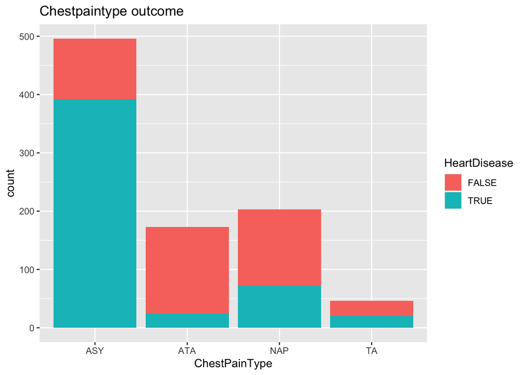

Fig 5. Ratio of diagnosis grouped by chestpain type

```
##
##       FALSE TRUE
##   ASY   104  392
##   ATA   149   24
##   NAP   131   72
##   TA     26   20
```

As visible see in the above figure (fig 5.) the uttermost CPT with HD is asymptomic pain. After that Non-Angical Pain is the heighest altough more patients with NAP have no diagnosed HD, the same can be seen in TA where the ratio between having and not having HD is rougly the same as in NAP. ATA has by far the lowest ratio diagnosed HD.

### PCI plotting

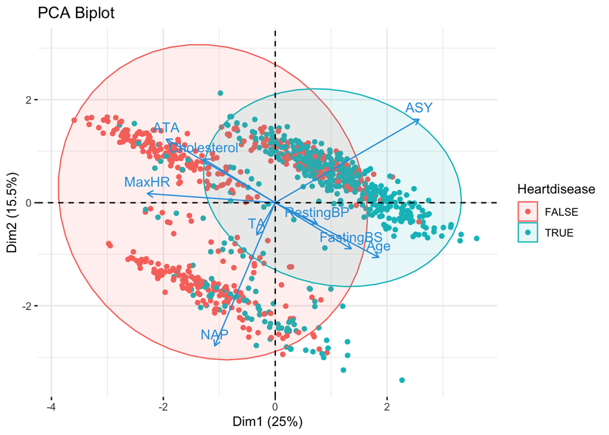

Fig 6. PCA Biplot of all non-categoral variables

In the above figure (fig 6) two clusters are visible. The turqoise cluster seems to be in correlation with ASY (asymptomic pain). Whereas there are two distinct negative clusters. The left upper cluster is affected by ATA, Max heartrate and cholesterol, while the left down clusters is effected by NAP.

To further see the contribution of each variable the underlying figure was generated.

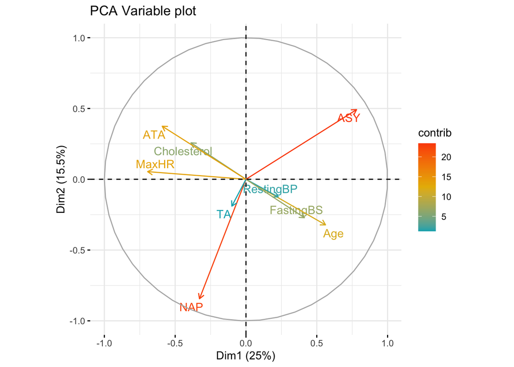

Fig 7. PCA Variable plot of all non-categoral variables

Figure 7 shows that both ASY and NAP are the biggest contributors between diagnoses.